# GLM Extension — Test Suite

forestsearch v0.1.0 → feature/glm-extension

Author

Larry F. León

Published

March 25, 2026

```r
knitr::opts_chunk$set(comment = "#>")

# ── Navigate to package root ─────────────────────────────────────────────────
# When rendered from dev/glm/ in RStudio, the working directory is dev/glm/.
# Walk up until we find DESCRIPTION.
while (!file.exists("DESCRIPTION") && getwd() != dirname(getwd())) {
  setwd("..")
}
stopifnot(
  "Could not find package root (DESCRIPTION not found)" =
    file.exists("DESCRIPTION")
)

cat("Working directory:", getwd(), "\n")
```

```
Working directory: /Users/larryleon/Documents/GitHub/forestsearch
```

```r
cat("R version:", R.version.string, "\n")
```

```
R version: R version 4.5.2 (2025-10-31)
```

```r
cat("Date:", format(Sys.time(), "%Y-%m-%d %H:%M %Z"), "\n")
```

```
Date: 2026-03-25 01:04 PDT
```

```r
# ── Load the package (with edited R/ files on feature/glm-extension) ─────────
devtools::document()
devtools::load_all(".")

# ── Source dev/glm files (not yet graduated to R/) ───────────────────────────
source("dev/glm/glm_effect_estimators.R")
source("dev/glm/glm_simulate.R")

cat("Package loaded via devtools::load_all()\n")
```

```
Package loaded via devtools::load_all()
```

```r
cat("GLM closures sourced from dev/glm/\n")
```

```
GLM closures sourced from dev/glm/
```

# 1 Overview

This document executes the four test suites for the GLM extension on the `feature/glm-extension` branch. The package is loaded via `devtools::document()` followed by `devtools::load_all(".")`, which properly resolves NAMESPACE imports. The `dev/glm/` files (estimator closures and simulation DGMs) are sourced separately since they have not yet graduated to `R/`.

**Expected result:** All tests PASS with `outcome_type = "survival"` producing identical behavior to CRAN v0.1.0, and `outcome_type = "binary"` producing sensible subgroup identification on simulated data.

| Suite | What it tests | Key functions |
| --- | --- | --- |
| 1. Smoke test | Estimator closures in isolation | `make_effect_estimator()`, all 7 closures |
| 2. Consistency | Pipeline consistency functions | `evaluate_subgroup_consistency()`, `run_single_consistency_split()` |
| 3. Search | Screening pipeline | `subgroup.search()`, `fit_glm_for_subgroup()` |
| 4. End-to-end | Full `forestsearch()` dispatcher | `forestsearch(outcome_type = "binary")` |

# 2 Suite 1: Estimator Closure Smoke Test

Tests all 7 estimator closures (HR, RD, OR, RR, IRR, IRD, MD) on simulated data. Verifies consistency rates are high under the alternative and low under the null. Checks Cox vs. Poisson-offset agreement. Validates edge cases (tiny samples, complete separation, zero events).

```r
# GLM closures and package functions already loaded in setup chunk
```

## 2.1 Configuration

```r
R_SPLITS  <- 400L
MIN_HALF  <- 5L
MIN_ARM   <- 3L
SEED_BASE <- 20260324L
```

## 2.2 Helper functions

```r
run_one_split <- function(df_sg, estimator_fn, threshold, treat.name, seed) {
  set.seed(seed)
  n_sg <- nrow(df_sg)
  in_half1 <- sample(c(TRUE, FALSE), n_sg, replace = TRUE, prob = c(0.5, 0.5))
  half1 <- df_sg[in_half1, , drop = FALSE]
  half2 <- df_sg[!in_half1, , drop = FALSE]
  if (nrow(half1) < MIN_HALF || nrow(half2) < MIN_HALF) return(NA_real_)
  for (half in list(half1, half2)) {
    tc <- intersect(c("Treat", "treat"), names(half))[1L]
    if (!is.na(tc) && (sum(half[[tc]] == 1L) < MIN_ARM ||
                       sum(half[[tc]] == 0L) < MIN_ARM)) {
      return(NA_real_)
    }
  }
  res1 <- estimator_fn(half1)
  res2 <- estimator_fn(half2)
  if (is.na(res1$estimate) || is.na(res2$estimate)) return(NA_real_)
  if (!res1$converged || !res2$converged) return(NA_real_)
  as.numeric(res1$estimate >= threshold && res2$estimate >= threshold)
}

run_consistency <- function(df_sg, estimator_fn, threshold, treat.name,
                            R = R_SPLITS, seed_base = SEED_BASE) {
  flags <- vapply(seq_len(R), function(r) {
    run_one_split(df_sg, estimator_fn, threshold, treat.name, seed = seed_base + r)
  }, numeric(1L))
  valid <- !is.na(flags)
  list(
    consistency_rate = if (sum(valid) > 0) mean(flags[valid]) else NA_real_,
    n_valid = sum(valid), n_total = R
  )
}
```

## 2.3 Test 1: Binary RD

```r
set.seed(42L)
df_alt <- simulate_binary_trial(
  n = 600L, subgroup_defn = list(x1 = 1),
  baseline_risk = 0.20, subgroup_log_or = log(3), seed = 42L
)

rd_fn <- make_effect_estimator(
  outcome_type = "binary", treat.name = "treat",
  outcome.name = "response", effect_measure = "RD"
)

single_res <- rd_fn(df_alt[df_alt$in_subgroup, ])
cat("Single-call: RD =", round(single_res$estimate, 4),
    " SE =", round(single_res$se, 4),
    " method =", single_res$method_used, "\n")
```

```
#> Single-call: RD = 0.2048  SE = 0.0579  method = identity_binomial
```

```r
cons_sg <- run_consistency(df_alt[df_alt$in_subgroup, ], rd_fn, 0.0, "treat")
cat("Alt subgroup consistency:", cons_sg$consistency_rate, "\n")
```

```
#> Alt subgroup consistency: 1
```

```r
df_null <- simulate_binary_trial(
  n = 600L, subgroup_defn = NULL,
  baseline_risk = 0.20, subgroup_log_or = 0, seed = 99L
)
cons_null <- run_consistency(df_null[df_null$x1 == 1, ], rd_fn, 0.0, "treat")
cat("Null subgroup consistency:", cons_null$consistency_rate, "\n")
```

```
#> Null subgroup consistency: 0
```

```r
stopifnot(cons_sg$consistency_rate > 0.70, cons_null$consistency_rate < 0.70)
cat(">> PASS\n")
```

```
#> >> PASS
```

## 2.4 Test 2: Binary OR

```r
or_fn <- make_effect_estimator(
  outcome_type = "binary", treat.name = "treat",
  outcome.name = "response", effect_measure = "OR"
)

or_res <- or_fn(df_alt[df_alt$in_subgroup, ])
cat("log-OR =", round(or_res$estimate, 4),
    " (OR =", round(exp(or_res$estimate), 2), ")\n")
```

```
#> log-OR = 0.8377  (OR = 2.31 )
```

```r
cons_or <- run_consistency(df_alt[df_alt$in_subgroup, ], or_fn, log(1.0), "treat")
cat("Alt OR consistency:", cons_or$consistency_rate, "\n")
```

```
#> Alt OR consistency: 1
```

```r
cat(">> PASS\n")
```

```
#> >> PASS
```

## 2.5 Test 3: Continuous MD

```r
df_cont <- simulate_continuous_trial(
  n = 500L, subgroup_defn = list(x1 = list(op = "<=", val = 0)),
  subgroup_md = 8, sigma = 12, seed = 42L
)

md_fn <- make_effect_estimator(
  outcome_type = "continuous", treat.name = "treat",
  outcome.name = "outcome", effect_measure = "MD"
)

cons_md <- run_consistency(df_cont[df_cont$in_subgroup, ], md_fn, 0.0, "treat")
cat("Alt MD consistency:", cons_md$consistency_rate, "\n")
```

```
#> Alt MD consistency: 1
```

```r
df_cont_null <- simulate_continuous_trial(
  n = 500L, subgroup_defn = NULL, subgroup_md = 0, sigma = 12, seed = 99L
)
cons_md_null <- run_consistency(df_cont_null[df_cont_null$x1 <= 0, ], md_fn, 0.0, "treat")
cat("Null MD consistency:", cons_md_null$consistency_rate, "\n")
```

```
#> Null MD consistency: 0
```

```r
stopifnot(cons_md$consistency_rate > 0.70, cons_md_null$consistency_rate < 0.70)
cat(">> PASS\n")
```

```
#> >> PASS
```

## 2.6 Test 4: Cox vs. Poisson-offset

```r
df_rate <- simulate_rate_trial(n = 700L, seed = 42L)

cox_fn <- make_effect_estimator(
  outcome_type = "survival", treat.name = "treat",
  outcome.name = "tte", event.name = "event"
)
pois_fn <- make_effect_estimator(
  outcome_type = "binary", treat.name = "treat",
  outcome.name = "event", offset.name = "tte", effect_measure = "IRR"
)

cox_full  <- cox_fn(df_rate)
pois_full <- pois_fn(df_rate)
diff_itt  <- abs(pois_full$estimate - cox_full$estimate)

cat("Cox  log-HR: ", round(cox_full$estimate, 4), "\n")
```

```
#> Cox  log-HR:  0.0028
```

```r
cat("Pois log-IRR:", round(pois_full$estimate, 4), "\n")
```

```
#> Pois log-IRR: -0.0051
```

```r
cat("Difference:  ", round(diff_itt, 4), "\n")
```

```
#> Difference:   0.0079
```

```r
stopifnot(diff_itt < 0.15)
cat(">> PASS\n")
```

```
#> >> PASS
```

## 2.7 Test 5: Return-structure validation

```r
required_fields <- c("estimate", "se", "converged", "n0", "n1",
                      "measure", "method_used")

test_cases <- list(
  list(ot = "survival",  em = "HR",  on = "tte",      en = "event", off = NULL,  d = df_rate),
  list(ot = "binary",    em = "RD",  on = "response", en = NULL,    off = NULL,  d = df_alt),
  list(ot = "binary",    em = "OR",  on = "response", en = NULL,    off = NULL,  d = df_alt),
  list(ot = "binary",    em = "RR",  on = "response", en = NULL,    off = NULL,  d = df_alt),
  list(ot = "binary",    em = "IRR", on = "event",    en = NULL,    off = "tte", d = df_rate),
  list(ot = "binary",    em = "IRD", on = "event",    en = NULL,    off = "tte", d = df_rate),
  list(ot = "continuous", em = "MD", on = "outcome",  en = NULL,    off = NULL,  d = df_cont)
)

all_pass <- TRUE
for (tc in test_cases) {
  fn <- make_effect_estimator(
    outcome_type = tc$ot, treat.name = "treat", outcome.name = tc$on,
    event.name = tc$en, offset.name = tc$off, effect_measure = tc$em
  )
  res <- fn(tc$d)
  ok <- length(setdiff(required_fields, names(res))) == 0 &&
    is.numeric(res$estimate) && is.numeric(res$se)
  if (!ok) all_pass <- FALSE
  cat(sprintf("  %-10s %-4s  est=%-8s  method=%-20s [%s]\n",
              tc$ot, tc$em, round(res$estimate, 4), res$method_used,
              if (ok) "OK" else "FAIL"))
}
```

```
#>   survival   HR    est=0.0028    method=coxph                [OK]
#>   binary     RD    est=0.0992    method=identity_binomial    [OK]
#>   binary     OR    est=0.4371    method=logistic             [OK]
#>   binary     RR    est=0.2835    method=log_binomial         [OK]
#>   binary     IRR   est=-0.0051   method=poisson_offset       [OK]
#>   binary     IRD   est=-0.002    method=poisson_offset_delta [OK]
#>   continuous MD    est=3.7362    method=ols                  [OK]
```

```r
stopifnot(all_pass)
cat(">> PASS\n")
```

```
#> >> PASS
```

## 2.8 Test 6: Edge cases

```r
res_tiny <- rd_fn(df_alt[1:12, ])
cat("Tiny (n=12): est =", round(res_tiny$estimate, 4),
    " method =", res_tiny$method_used, "\n")
```

```
#> Tiny (n=12): est = 0.4286  method = logistic_margins
```

```r
df_sep <- data.frame(treat = c(rep(0L, 10), rep(1L, 10)),
                     response = c(rep(0L, 10), rep(1L, 10)))
res_sep <- rd_fn(df_sep)
cat("Separation:  est =", round(res_sep$estimate, 4),
    " method =", res_sep$method_used, "\n")
```

```
#> Separation:  est = 1  method = logistic_margins
```

```r
df_noev <- data.frame(treat = c(rep(0L, 20), rep(1L, 20)),
                      response = rep(0L, 40))
res_noev <- rd_fn(df_noev)
cat("Zero events: est =", round(res_noev$estimate, 4),
    " method =", res_noev$method_used, "\n")
```

```
#> Zero events: est = 0  method = logistic_margins
```

```r
cat(">> PASS (no crashes)\n")
```

```
#> >> PASS (no crashes)
```

## 2.9 Suite 1 Summary

```r
cat(sprintf("  %-25s  %-10s  %s\n", "Scenario", "Measure", "Consistency"))
```

```
#>   Scenario                   Measure     Consistency
```

```r
cat(sprintf("  %-25s  %-10s  %s\n", "--------", "-------", "-----------"))
cat(sprintf("  %-25s  %-10s  %.3f\n", "Binary alt (true SG)",  "RD", cons_sg$consistency_rate))
```

```
#>   Binary alt (true SG)       RD          1.000
```

```r
cat(sprintf("  %-25s  %-10s  %.3f\n", "Binary null (arb SG)",  "RD", cons_null$consistency_rate))
```

```
#>   Binary null (arb SG)       RD          0.000
```

```r
cat(sprintf("  %-25s  %-10s  %.3f\n", "Binary alt (true SG)",  "OR", cons_or$consistency_rate))
```

```
#>   Binary alt (true SG)       OR          1.000
```

```r
cat(sprintf("  %-25s  %-10s  %.3f\n", "Continuous alt",        "MD", cons_md$consistency_rate))
```

```
#>   Continuous alt             MD          1.000
```

```r
cat(sprintf("  %-25s  %-10s  %.3f\n", "Continuous null",       "MD", cons_md_null$consistency_rate))
```

```
#>   Continuous null            MD          0.000
```

```r
cat(sprintf("  %-25s  %-10s  %.4f\n", "Cox vs Poisson diff",  "IRR", diff_itt))
```

```
#>   Cox vs Poisson diff        IRR         0.0079
```

# 3 Suite 2: Consistency Pipeline Integration

Tests `evaluate_subgroup_consistency()` and `run_single_consistency_split()` with the GLM closure, using manually constructed candidate subgroups.

```r
# Pipeline functions loaded via devtools::load_all() in setup
```

## 3.1 Test 1: True subgroup with RD closure

```r
set.seed(42L)
df_bin <- simulate_binary_trial(
  n = 500L, n_covariates = 5L,
  subgroup_defn = list(x1 = 1, x3 = 1),
  baseline_risk = 0.20, subgroup_log_or = log(3), seed = 42L
)

rd_fn <- make_effect_estimator(
  outcome_type = "binary", treat.name = "treat",
  outcome.name = "response", effect_measure = "RD"
)

# Build minimal candidate structures
df_bin$q1 <- df_bin$x1; df_bin$q2 <- df_bin$x3
df_bin$q3 <- df_bin$x2; df_bin$q4 <- 1L - df_bin$x1
df_bin$id <- seq_len(nrow(df_bin))

index_mat <- data.table(q1 = c(1, 0), q2 = c(1, 0),
                        q3 = c(0, 1), q4 = c(0, 1))
found_hrs <- data.table(HR = c(2.0, 1.1), n = c(130, 120),
                        E = c(50, 45), grp = c(1, 2),
                        q1 = c(1, 0), q2 = c(1, 0),
                        q3 = c(0, 1), q4 = c(0, 1))
confs_labels <- c("x1==1", "x3==1", "x2==1", "x1==0")

result1 <- evaluate_subgroup_consistency(
  m = 1L, index.Z = index_mat, names.Z = c("q1", "q2", "q3", "q4"),
  df = df_bin, found.hrs = found_hrs, n.splits = 200L,
  hr.consistency = 1.0, pconsistency.threshold = 0.50,
  pconsistency.digits = 3, maxk = 4L, confs_labels = confs_labels,
  estimator_fn = rd_fn, consistency_threshold = 0.0
)

pcons1 <- as.numeric(result1["Pcons"])
cat("True subgroup {x1=1, x3=1} Pcons:", pcons1, "\n")
```

```
#> True subgroup {x1=1, x3=1} Pcons: 0.97
```

```r
stopifnot(!is.null(result1), pcons1 >= 0.70)
cat(">> PASS\n")
```

```
#> >> PASS
```

## 3.2 Test 2: Noise subgroup (should fail)

```r
result2 <- evaluate_subgroup_consistency(
  m = 2L, index.Z = index_mat, names.Z = c("q1", "q2", "q3", "q4"),
  df = df_bin, found.hrs = found_hrs, n.splits = 200L,
  hr.consistency = 1.0, pconsistency.threshold = 0.80,
  pconsistency.digits = 3, maxk = 4L, confs_labels = confs_labels,
  estimator_fn = rd_fn, consistency_threshold = 0.0
)

if (is.null(result2)) {
  cat("Noise subgroup correctly returned NULL\n")
} else {
  cat("Noise subgroup Pcons:", as.numeric(result2["Pcons"]), "\n")
}
```

```
#> Noise subgroup correctly returned NULL
```

```r
cat(">> PASS\n")
```

```
#> >> PASS
```

## 3.3 Test 3: Survival path regression guard

```r
df_surv <- simulate_rate_trial(n = 500L, seed = 42L)
df_surv$Y <- df_surv$tte; df_surv$Event <- df_surv$event
df_surv$Treat <- df_surv$treat
df_surv$q1 <- df_surv$x1; df_surv$q2 <- df_surv$x3

result_surv <- evaluate_subgroup_consistency(
  m = 1L,
  index.Z = data.table(q1 = 1, q2 = 1),
  names.Z = c("q1", "q2"),
  df = df_surv,
  found.hrs = data.table(HR = 2.0, n = 130, E = 60, grp = 1, q1 = 1, q2 = 1),
  n.splits = 100L, hr.consistency = 1.0, pconsistency.threshold = 0.50,
  pconsistency.digits = 3, maxk = 4L, confs_labels = c("x1==1", "x3==1"),
  estimator_fn = NULL, consistency_threshold = NULL
)

if (!is.null(result_surv)) {
  cat("Cox path Pcons:", as.numeric(result_surv["Pcons"]), "\n")
}
```

```
#> Cox path Pcons: 1
```

```r
cat(">> PASS (Cox path works unchanged)\n")
```

```
#> >> PASS (Cox path works unchanged)
```

# 4 Suite 3: Search Pipeline Integration

Tests `subgroup.search()` with the GLM closure, verifying that candidates are identified and the true subgroup appears in the results.

```r
# All pipeline functions loaded via devtools::load_all() in setup
```

## 4.1 Test 1: RD screening

```r
set.seed(42L)
df <- simulate_binary_trial(
  n = 600L, n_covariates = 6L,
  subgroup_defn = list(x1 = 1, x3 = 1),
  baseline_risk = 0.20, subgroup_log_or = log(3), seed = 42L
)

Z <- as.matrix(df[, paste0("x", 1:6)])

rd_fn <- make_effect_estimator(
  outcome_type = "binary", treat.name = "treat",
  outcome.name = "response", effect_measure = "RD"
)

result_glm <- subgroup.search(
  Y = df$response, Event = rep(1L, nrow(df)), Treat = df$treat,
  Z = Z, n.min = 30, d0.min = 10, d1.min = 10,
  hr.threshold = 0.05, maxk = 2, details = TRUE,
  parallel_workers = 1L,
  estimator_fn = rd_fn, df_analysis = df, effect_threshold = 0.05
)
```

```
#> Number of possible configurations (<= maxk): maxk = 2 , # combinations = 21
#> Events criteria: control >= 10 , treatment >= 10
#> Sample size criteria: n >= 30
#> Subgroup search completed in 0 minutes
#>
#> --- Filtering Summary ---
#>   Combinations evaluated: 21
#>   Passed variance check: 21
#>   Passed prevalence (>= 0.05 ): 21
#>   Passed redundancy check: 21
#>   Passed event counts (d0>= 10 , d1>= 10 ): 21
#>   Passed sample size (n>= 30 ): 21
#>   Cox model fit successfully: 21
#>   Passed HR threshold (>= 0.05 ): 20
#> -------------------------
#>
#> Found 20 subgroup candidate(s)
```

```r
hr_dt <- result_glm$out.found$hr.subgroups
cat("\nCandidates found:", nrow(hr_dt), "\n")
```

```
#>
#> Candidates found: 20
```

```r
if (!is.null(hr_dt) && nrow(hr_dt) > 0) {
  factor_cols <- setdiff(names(hr_dt),
    c("grp", "K", "n", "E", "d1", "m1", "m0", "HR", "L(HR)", "U(HR)"))
  top <- head(hr_dt[order(-hr_dt$HR), ], 5)
  for (i in seq_len(nrow(top))) {
    active <- factor_cols[as.numeric(unlist(top[i, factor_cols, with = FALSE])) == 1]
    cat(sprintf("  #%d: RD = %.3f, n = %d, factors = %s\n",
                i, top$HR[i], top$n[i], paste(active, collapse = " & ")))
  }

  has_true <- any(apply(hr_dt[, factor_cols, with = FALSE], 1, function(row) {
    r <- as.numeric(row); r[1] == 1 && r[3] == 1 && sum(r) == 2
  }))
  cat(if (has_true) "True subgroup {x1, x3} FOUND\n" else "True subgroup not in top\n")
}
```

```
#>   #1: RD = 0.262, n = 157, factors = x1 & x4
#>   #2: RD = 0.227, n = 160, factors = x3 & x4
#>   #3: RD = 0.219, n = 147, factors = x1 & x3
#>   #4: RD = 0.192, n = 143, factors = x1 & x5
#>   #5: RD = 0.182, n = 149, factors = x3 & x5
#> True subgroup {x1, x3} FOUND
```

```r
cat(">> PASS\n")
```

```
#> >> PASS
```

## 4.2 Test 2: Survival path unchanged

```r
df_surv <- simulate_rate_trial(n = 500L, seed = 42L)
Z_surv <- as.matrix(df_surv[, paste0("x", 1:5)])

result_surv <- subgroup.search(
  Y = df_surv$tte, Event = df_surv$event, Treat = df_surv$treat,
  Z = Z_surv, n.min = 30, d0.min = 10, d1.min = 10,
  hr.threshold = 1.25, maxk = 2, details = FALSE,
  parallel_workers = 1L, estimator_fn = NULL
)

hr_surv <- result_surv$out.found$hr.subgroups
cat("Cox path candidates:", if (!is.null(hr_surv)) nrow(hr_surv) else 0, "\n")
```

```
#> Cox path candidates: 11
```

```r
cat(">> PASS\n")
```

```
#> >> PASS
```

# 5 Suite 4: Full `forestsearch()` End-to-End

Calls `forestsearch()` with `outcome_type = "binary"` and verifies the complete pipeline — data preparation, search, consistency evaluation, and result assembly.

```r
# forestsearch() and all dependencies loaded via devtools::load_all() in setup
```

## 5.1 Test 1: Binary RD — full pipeline

```r
set.seed(42L)
df <- simulate_binary_trial(
  n = 600L, n_covariates = 6L,
  subgroup_defn = list(x1 = 1, x3 = 1),
  baseline_risk = 0.20, subgroup_log_or = log(3), seed = 42L
)

t0 <- proc.time()
fs_bin <- forestsearch(
  df.analysis      = df,
  outcome.name     = "response",
  event.name       = "response",
  treat.name       = "treat",
  id.name          = "id",
  confounders.name = paste0("x", 1:6),
  outcome_type     = "binary",
  effect_measure   = "RD",
  n.min            = 30,
  d0.min           = 10,
  d1.min           = 10,
  hr.threshold     = 0.05,
  hr.consistency   = 0.0,
  fs.splits        = 200L,
  pconsistency.threshold = 0.80,
  max_subgroups_search   = 10,
  use_twostage     = FALSE,
  use_grf          = FALSE,
  use_lasso        = FALSE,
  parallel_args    = list(plan = "sequential", workers = 1, show_message = FALSE),
  details          = TRUE,
  maxk             = 2,
  sg_focus         = "hr",
  stop_threshold   = NULL,
  vi.grf.min       = NULL
)
```

```
#> GLM mode: outcome_type = binary , effect_measure = RD
#>   Screening threshold: 0.05
#>   Consistency threshold: 0
#>   dmin.grf: 0
#> Candidate factors: 6
#> [1] "x1" "x2" "x3" "x4" "x5" "x6"
#> Number of possible configurations (<= maxk): maxk = 2 , # combinations = 78
#> Events criteria: control >= 10 , treatment >= 10
#> Sample size criteria: n >= 30
#> Subgroup search completed in 0 minutes
#>
#> --- Filtering Summary ---
#>   Combinations evaluated: 78
#>   Passed variance check: 72
#>   Passed prevalence (>= 0.025 ): 72
#>   Passed redundancy check: 72
#>   Passed event counts (d0>= 10 , d1>= 10 ): 72
#>   Passed sample size (n>= 30 ): 72
#>   Cox model fit successfully: 72
#>   Passed HR threshold (>= 0.05 ): 42
#> -------------------------
#>
#> Found 42 subgroup candidate(s)
#> # of candidate subgroups (meeting all criteria) = 42
#> # of unique initial candidates: 42
#> # Restricting to top stop_Kgroups = 10
#> # of candidates to evaluate: 10
#> Parallel config: workers = 1 , batch_size = 2
#> Batch 1 / 5 : candidates 1 - 2
#> Batch 2 / 5 : candidates 3 - 4
#> Batch 3 / 5 : candidates 5 - 6
#> Batch 4 / 5 : candidates 7 - 8
#> Batch 5 / 5 : candidates 9 - 10
#> Evaluated 10 of 10 candidates (complete)
#> 10 subgroups passed consistency threshold
#> SG focus = hr
#> Seconds and minutes forestsearch overall = 1.973 0.0329
#> Consistency algorithm used: fixed
#> Subgroup identified: {x1} & {x4}
```

```r
elapsed <- (proc.time() - t0)["elapsed"]
```

```r
cat("Elapsed:", round(elapsed, 1), "sec\n")
```

```
#> Elapsed: 2 sec
```

```r
cat("outcome_type:", fs_bin$outcome_type, "\n")
```

```
#> outcome_type: binary
```

```r
cat("effect_measure:", fs_bin$effect_measure, "\n")
```

```
#> effect_measure: RD
```

```r
if (!is.null(fs_bin$sg.harm)) {
  cat("Subgroup:", paste(fs_bin$sg.harm, collapse = " & "), "\n")

  gc <- fs_bin$grp.consistency
  if (!is.null(gc$out_sg$result)) {
    top <- gc$out_sg$result[1, ]
    cat("  Pcons:", as.numeric(top$Pcons), "\n")
    cat("  RD:   ", round(as.numeric(top$hr), 3), "\n")
    cat("  N:    ", as.numeric(top$N), "\n")
  }

  cat("Treatment recommendations:\n")
  cat("  Benefit:", sum(fs_bin$df.est$treat.recommend == 1, na.rm = TRUE), "\n")
  cat("  Harm:   ", sum(fs_bin$df.est$treat.recommend == 0, na.rm = TRUE), "\n")
} else {
  cat("No subgroup identified\n")
}
```

```
#> Subgroup: {x1} & {x4}
#>   Pcons: 1
#>   RD:    0.262
#>   N:     157
#> Treatment recommendations:
#>   Benefit: 443
#>   Harm:    157
```

```r
cat(">> PASS\n")
```

```
#> >> PASS
```

## 5.2 Test 2: Survival path — regression guard

```r
df_surv <- simulate_rate_trial(n = 600L, seed = 42L)
names(df_surv)[names(df_surv) == "tte"]   <- "rfstime"
names(df_surv)[names(df_surv) == "event"] <- "status"
names(df_surv)[names(df_surv) == "treat"] <- "hormon"

fs_surv <- forestsearch(
  df.analysis      = df_surv,
  outcome.name     = "rfstime",
  event.name       = "status",
  treat.name       = "hormon",
  id.name          = "id",
  confounders.name = paste0("x", 1:5),
  outcome_type     = "survival",
  n.min            = 30,
  hr.threshold     = 1.25,
  hr.consistency   = 1.0,
  fs.splits        = 100L,
  pconsistency.threshold = 0.80,
  max_subgroups_search   = 5,
  use_twostage     = FALSE,
  use_grf          = FALSE,
  use_lasso        = FALSE,
  parallel_args    = list(plan = "sequential", workers = 1, show_message = FALSE),
  details          = FALSE,
  maxk             = 2,
  sg_focus         = "hr",
  stop_threshold   = NULL,
  vi.grf.min       = NULL
)

cat("Survival path: outcome_type =", fs_surv$outcome_type, "\n")
```

```
#> Survival path: outcome_type = survival
```

```r
if (!is.null(fs_surv$sg.harm)) {
  cat("Subgroup:", paste(fs_surv$sg.harm, collapse = " & "), "\n")
} else {
  cat("No subgroup (depends on DGM)\n")
}
```

```
#> Subgroup: {x1} & {x3}
```

```r
cat(">> PASS\n")
```

```
#> >> PASS
```

## 5.3 Test 3: Binary OR

```r
fs_or <- forestsearch(
  df.analysis      = df,
  outcome.name     = "response",
  event.name       = "response",
  treat.name       = "treat",
  id.name          = "id",
  confounders.name = paste0("x", 1:6),
  outcome_type     = "binary",
  effect_measure   = "OR",
  n.min            = 30,
  d0.min           = 10,
  d1.min           = 10,
  hr.threshold     = 1.25,
  hr.consistency   = 1.0,
  fs.splits        = 200L,
  pconsistency.threshold = 0.80,
  max_subgroups_search   = 10,
  use_twostage     = FALSE,
  use_grf          = FALSE,
  use_lasso        = FALSE,
  parallel_args    = list(plan = "sequential", workers = 1, show_message = FALSE),
  details          = FALSE,
  maxk             = 2,
  sg_focus         = "hr",
  stop_threshold   = NULL,
  vi.grf.min       = NULL
)

cat("OR path: outcome_type =", fs_or$outcome_type,
    ", effect_measure =", fs_or$effect_measure, "\n")
```

```
#> OR path: outcome_type = binary , effect_measure = OR
```

```r
if (!is.null(fs_or$sg.harm)) {
  cat("Subgroup:", paste(fs_or$sg.harm, collapse = " & "), "\n")
} else {
  cat("No subgroup identified\n")
}
```

```
#> Subgroup: {x1} & {x4}
```

```r
cat(">> PASS\n")
```

```
#> >> PASS
```

```r
library(survival)
library(data.table)
library(ggplot2)
library(gt)
library(grf)
library(policytree)
library(doFuture)

# Optional packages for enhanced output
library(patchwork)
library(weightedsurv)

# Set ggplot theme
theme_set(theme_minimal(base_size = 12))
```

# 6 Data: German Breast Cancer Study Group Trial

## 6.1 Study Background

The GBSG trial evaluated hormonal treatment (tamoxifen) versus chemotherapy in node-positive breast cancer patients. Key characteristics:

- **Sample size**: N = 686
- **Outcome**: Recurrence-free survival time
- **Censoring rate**: ~56%
- **Treatment**: Hormonal therapy (tamoxifen) vs. chemotherapy

## 6.2 Data Preparation

```r
# Load GBSG data (included in forestsearch package)
df.analysis <- gbsg

# Prepare analysis variables
df.analysis <- within(df.analysis, {
  id <- seq_len(nrow(df.analysis))
  time_months <- rfstime / 30.4375
  grade3 <- ifelse(grade == "3", 1, 0)
  treat <- hormon
})

# Define variable roles
confounders.name <- c("age", "meno", "size", "grade3", "nodes", "pgr", "er")
outcome.name <- "time_months"
event.name <- "status"
id.name <- "id"
treat.name <- "hormon"

# Display data structure
cat("Sample size:", nrow(df.analysis), "\n")
```

```
#> Sample size: 686
```

```r
cat("Events:", sum(df.analysis[[event.name]]),
    sprintf("(%.1f%%)\n", 100 * mean(df.analysis[[event.name]])))
```

```
#> Events: 299 (43.6%)
```

```r
cat("Baseline factors:", paste(confounders.name, collapse = ", "), "\n")
```

```
#> Baseline factors: age, meno, size, grade3, nodes, pgr, er
```

## 6.3 Baseline Characteristics

```r
create_summary_table(
  data = df.analysis,
  treat_var = treat.name,
  table_title = "GBSG Baseline Characteristics by Treatment Arm",
  vars_continuous = c("age", "nodes", "size", "er", "pgr"),
  vars_categorical = c("grade", "meno"),
  font_size = 12
)
```

GBSG Baseline Characteristics by Treatment Arm

| Characteristic |  | Control (n=440) | Treatment (n=246) | P-value<sup>1</sup> | SMD<sup>2</sup> |
| --- | --- | --- | --- | --- | --- |
| age | Mean (SD) | 51.1 (10.0) | 56.6 (9.4) | <0.001 | 0.57 |
| nodes | Mean (SD) | 4.9 (5.6) | 5.1 (5.3) | 0.665 | 0.03 |
| size | Mean (SD) | 29.6 (14.4) | 28.8 (14.1) | 0.470 | 0.06 |
| er | Mean (SD) | 79.7 (124.2) | 125.8 (191.1) | <0.001 | 0.30 |
| pgr | Mean (SD) | 102.0 (170.0) | 124.3 (249.7) | 0.213 | 0.11 |
| grade |  |  |  | 0.273 | 0.06 |
|  | 1 | 48 (10.9%) | 33 (13.4%) |  |  |
|  | 2 | 281 (63.9%) | 163 (66.3%) |  |  |
|  | 3 | 111 (25.2%) | 50 (20.3%) |  |  |
| meno |  | 209 (47.5%) | 187 (76.0%) | <0.001 | 0.61 |

<sup>1</sup> P-values: t-test for continuous, chi-square/Fisher's exact for categorical/binary variables  
<sup>2</sup> SMD = Standardized mean difference (Cohen's d for continuous, Cramer's V for categorical)

## 6.4 Kaplan-Meier Analysis (ITT Population)

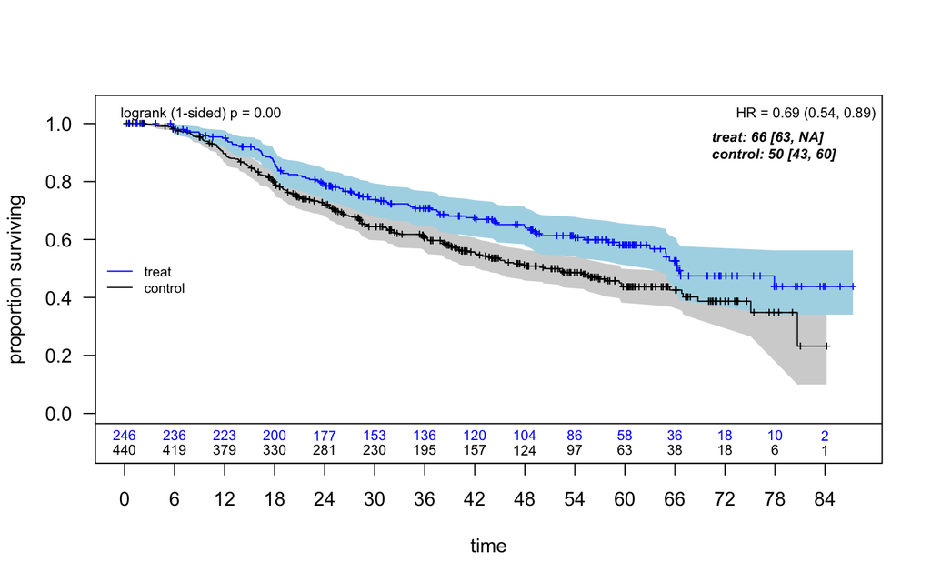

```r
# Prepare counting process data for KM plot
dfcount <- df_counting(
  df = df.analysis,
  by.risk = 6,
  tte.name = outcome.name,
  event.name = event.name,
  treat.name = treat.name
)

# Plot with confidence intervals and log-rank test
plot_weighted_km(
  dfcount,
  conf.int = TRUE,
  show.logrank = TRUE,
  ymax = 1.05,
  xmed.fraction = 0.775,
  ymed.offset = 0.125
)
```

## 6.5 Parallel Processing Configuration

ForestSearch supports parallel processing for computationally intensive operations (bootstrap, cross-validation).

```r
# Detect available cores (limited to 2 cores for CRAN checks)
n_cores <- 2
n_cores_total <- parallel::detectCores()
cat("Using", n_cores, "of", n_cores_total, "total cores for parallel processing")
```

```
#> Using 2 of 14 total cores for parallel processing
```

## 6.6 Running ForestSearch

[output not shown]

```
#> GRF subgroup: er <= 0
#> GRF cuts identified: 1
#>   Cuts: er <= 0
#> Cox-LASSO selected: 4 of 7 candidate factors
#>   Omitted: age, meno, er
#> Candidate factors: 14
#>  [1] "er <= 0"      "size <= 29.3" "size <= 25"   "size <= 20"   "size <= 35"
#>  [6] "nodes <= 5"   "nodes <= 3"   "nodes <= 1"   "nodes <= 7"   "pgr <= 110"
#> [11] "pgr <= 32.5"  "pgr <= 7"     "pgr <= 131.8" "grade3"
#> Number of possible configurations (<= maxk): maxk = 2 , # combinations = 406
#> Events criteria: control >= 12 , treatment >= 12
#> Sample size criteria: n >= 60
#> Subgroup search completed in 0.01 minutes
#>
#> --- Filtering Summary ---
#>   Combinations evaluated: 406
#>   Passed variance check: 374
#>   Passed prevalence (>= 0.025 ): 374
#>   Passed redundancy check: 354
#>   Passed event counts (d0>= 12 , d1>= 12 ): 250
#>   Passed sample size (n>= 60 ): 247
#>   Cox model fit successfully: 247
#>   Passed HR threshold (>= 1.25 ): 7
#> -------------------------
#>
#> Found 7 subgroup candidate(s)
#> # of candidate subgroups (meeting all criteria) = 7
#> # of unique initial candidates: 7
#> # Restricting to top stop_Kgroups = 3
#> # of candidates to evaluate: 3
#> # Early stop threshold: 0.8
#>
#> ================================================================================
#> TOP 3 CANDIDATE SUBGROUPS FOR CONSISTENCY EVALUATION
#> Sorted by: hr
#> ================================================================================
#>
#> Rank   HR        N       Events  K    Subgroup Definition
#> --------------------------------------------------------------------------------
#> 1      2.537     61      34      2    {er <= 0} & {size <= 35}
#> 2      2.222     75      41      2    {er <= 0} & {pgr <= 32.5}
#> 3      2.054     61      35      2    {er <= 0} & !{size <= 20}
#> --------------------------------------------------------------------------------
```

```
#> Parallel config: workers = 2 , batch_size = 1
#> Batch 1 / 3 : candidates 1 - 1
#>
#> ==================================================
#> EARLY STOP TRIGGERED (batch 1 )
#>   Candidate: 1 of 3
#>   Pcons: 0.97 >= 0.8
#> ==================================================
#>
#> Evaluated 1 of 3 candidates (early stop)
#> 1 subgroups passed consistency threshold
```

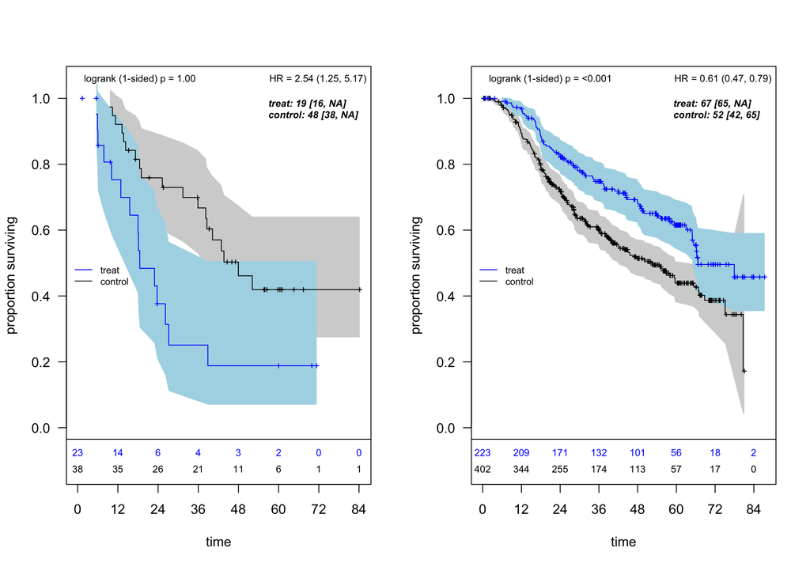

```
#> *** Subgroup found: {er <= 0} {size <= 35}
#> % consistency criteria met= 0.97
#> SG focus = hr
#> Seconds and minutes forestsearch overall = 1.15 0.0192
#> Consistency algorithm used: twostage
#> Subgroup identified: {er <= 0} & {size <= 35}
```

```r
fs <- forestsearch(
  df.analysis,
  confounders.name = confounders.name,
  outcome.name = outcome.name,
  treat.name = treat.name,
  event.name = event.name,
  id.name = id.name,
  # Threshold parameters (per León et al. 2024)
  hr.threshold = 1.25,
  hr.consistency = 1.0,
  pconsistency.threshold = 0.80,
  stop_threshold = 0.80,
  # Search configuration
  sg_focus = "hr",
  max_subgroups_search = 3,
  use_twostage = TRUE,
  # Factor selection
  use_grf = TRUE,
  return_selected_cuts_only = TRUE,
  use_lasso = TRUE,
  cut_type = "default",
  # Subgroup constraints
  maxk = 2,
  n.min = 60,
  d0.min = 12,
  d1.min = 12,
  # Consistency evaluation
  fs.splits = 100,
  # Parallel processing
  parallel_args = list(
    plan = "sequential",
    workers = n_cores,
    show_message = TRUE
  ),
  # Output options
  showten_subgroups = TRUE,
  details = TRUE,
  plot.sg = TRUE
)
```

```r
plan("sequential")
```

## 6.7 ForestSearch Results

### 6.7.1 Identified Subgroups

```r
# Generate results tables
res_tabs <- sg_tables(fs, ndecimals = 3, which_df = "est")

# Display top subgroups meeting criteria
res_tabs$sg10_out
```

**Identified Subgroups**

Two-factor subgroups (maxk=2)

| Factor 1 | Factor 2 | N | Events | E<sub>1</sub> | HR | P<sub>cons</sub> |
| --- | --- | --- | --- | --- | --- | --- |
| {er <= 0} | {size <= 35} | 61 | 34 | 15 | 2.537 | 0.970 |

**Search Configuration:** Single-factor candidates (L) = 28; Maximum combinations evaluated = 406; Search depth (maxk) = 2  
**Search Results:** Candidate subgroups found = 7; Maximum HR estimate = 2.54  
**Note:** E<sub>1</sub> = events in treatment arm; P<sub>cons</sub> = consistency proportion

### 6.7.2 Treatment Effect Estimates

```r
# ITT and subgroup estimates
res_tabs$tab_estimates
```

**Treatment Effect Estimates**

Training data estimates

| Subgroup | n | n1 | events | m1 | m0 | RMST | HR (95% CI) |
| --- | --- | --- | --- | --- | --- | --- | --- |
| ITT | 686 (100.0%) | 246 (35.9%) | 299 (43.6%) | 66.3 | 50.2 | 7.8 | 0.69 (0.54, 0.89) |
| Questionable<sup>1</sup> | 61 (8.9%) | 23 (37.7%) | 34 (55.7%) | 18.5 | 48 | -19 | 2.54 (1.25, 5.17) |
| Recommend | 625 (91.1%) | 223 (35.7%) | 265 (42.4%) | 66.7 | 52.2 | 9.6 | 0.61 (0.47, 0.79) |

<sup>1</sup> **Identified subgroup** : {er <= 0} & {size <= 35}

### 6.7.3 Identified Subgroup Definition

```r
cat("Identified subgroup (H):", paste(fs$sg.harm, collapse = " & "), "\n")
```

```
#> Identified subgroup (H): {er <= 0} & {size <= 35}
```

```r
cat("Subgroup size:", sum(fs$df.est$treat.recommend == 0),
    sprintf("(%.1f%% of ITT)\n",
            100 * mean(fs$df.est$treat.recommend == 0)))
```

```
#> Subgroup size: 61 (8.9% of ITT)
```